# Waddle We Do Without Penguins: A Data Science Exploration Into Antarctica's Penguins

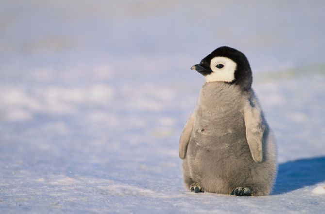

Image source: https://www.cabq.gov/artsculture/biopark/news/10-cool-facts-about-penguins

## Introduction

In today's ever-growing society, climate change is becoming a growing problem. As carbon dioxide levels rise, so does the rate at which coral reefs die off the oceans. Society continues to grow and produce, sometimes at the cost of the habitats of wildlife. Greenhouse gas emmissions and pollution continue to rise with the advent of cars and factories, and global temperatures have also reflected this trend. Many people have also turned their attention to the Earth's North and Southern poles. Every year the Earth's natural glaciers melt at an alarming rate, which further results in the loss of habitat for animals that inhabit these environments. One such animal consists of penguins. Antarctica is home to many penguin species, such as emperor penguins (as seen in Happy Feet!), king penguins, and macaroni penguins, among others. Although these penguins' habitats have become endangered, conservation efforts have been made to protect the wildlife in Antarctica, such as giving endangered animals homes in zoos and aquariums where they can be studied and nurtured.

One such dataset that exists is called Palmer's Penguins, which contains valuable data of approximately 344 penguins. In this dataset, a number of observations have been recorded about these penguins, such as their island of origin, species, bill length and depth, body mass in grams, and gender. This exploration aims to analyze these differences between three species of penguins: adelie, gentoo, and chinstrap. In it, we will explore how bill lengths, depths, and body mass differ between different penguin species and different genders. Furthermore, we will take a machine learning approach and attempt to use decision tree classification and k-NN classification methods to attempt to classify penguins into different species based upon their demographic attributes, as listed earlier. This project's ultimate goal to analyze these differences between penguin species and see if machine learning can be applied in this context to identify penguin species' based on their characteristics, which could ultimately lead to more effective penguin identification and conservation in the future.

## Data Collection

Here we import all the modules needed for analysis of the data:

```python
import pandas as pd
import matplotlib.pyplot as plt
import numpy as np
from sklearn import linear_model
import seaborn as sns
from sklearn.datasets import load_boston
from sklearn.datasets import load_iris
from sklearn.datasets import load_wine
from sklearn.model_selection import cross_val_score
from sklearn.preprocessing import PolynomialFeatures
from sklearn.model_selection import train_test_split

from sklearn import datasets
from sklearn import svm
from sklearn import tree
from sklearn.model_selection import GridSearchCV
from IPython.display import Image
from sklearn.model_selection import cross_val_score
from sklearn.tree import DecisionTreeClassifier
from sklearn.ensemble import RandomForestClassifier
from sklearn.neighbors import KNeighborsClassifier
import seaborn as sns
from sklearn.model_selection import cross_val_score
from sklearn.model_selection import KFold
import statsmodels.api as sm
import statsmodels.formula.api as smf
from statsmodels.graphics.regressionplots import abline_plot

from patsy import dmatrices, dmatrix, demo_data, ContrastMatrix, Poly
```

Here we read in the data into a dataframe using pandas. The dataset's source is from Kaggle, linked here: https://www.kaggle.com/parulpandey/palmer-archipelago-antarctica-penguin-data?select=penguins_size.csv

As an overview of the variables contained in the dataset, they are as follows: species: the penguin's species culmen_length_mm: bill length, measured in millimeters culmen_depth_mm: bill depth, measured in millimeters flipper_length_mm: flipper length, measured in milimeters body_mass_g: body mass, measured in grams sex: gender (male/female)

```python
df = pd.read_csv("penguins_size.csv")
df
```

|  | species | island | culmen_length_mm | culmen_depth_mm | flipper_length_mm | body_mass_g | sex |
| --- | --- | --- | --- | --- | --- | --- | --- |
| 0 | Adelie | Torgersen | 39.1 | 18.7 | 181.0 | 3750.0 | MALE |
| 1 | Adelie | Torgersen | 39.5 | 17.4 | 186.0 | 3800.0 | FEMALE |
| 2 | Adelie | Torgersen | 40.3 | 18.0 | 195.0 | 3250.0 | FEMALE |
| 3 | Adelie | Torgersen | NaN | NaN | NaN | NaN | NaN |
| 4 | Adelie | Torgersen | 36.7 | 19.3 | 193.0 | 3450.0 | FEMALE |
| 5 | Adelie | Torgersen | 39.3 | 20.6 | 190.0 | 3650.0 | MALE |
| 6 | Adelie | Torgersen | 38.9 | 17.8 | 181.0 | 3625.0 | FEMALE |
| 7 | Adelie | Torgersen | 39.2 | 19.6 | 195.0 | 4675.0 | MALE |
| 8 | Adelie | Torgersen | 34.1 | 18.1 | 193.0 | 3475.0 | NaN |
| 9 | Adelie | Torgersen | 42.0 | 20.2 | 190.0 | 4250.0 | NaN |
| 10 | Adelie | Torgersen | 37.8 | 17.1 | 186.0 | 3300.0 | NaN |
| 11 | Adelie | Torgersen | 37.8 | 17.3 | 180.0 | 3700.0 | NaN |
| 12 | Adelie | Torgersen | 41.1 | 17.6 | 182.0 | 3200.0 | FEMALE |
| 13 | Adelie | Torgersen | 38.6 | 21.2 | 191.0 | 3800.0 | MALE |
| 14 | Adelie | Torgersen | 34.6 | 21.1 | 198.0 | 4400.0 | MALE |
| 15 | Adelie | Torgersen | 36.6 | 17.8 | 185.0 | 3700.0 | FEMALE |
| 16 | Adelie | Torgersen | 38.7 | 19.0 | 195.0 | 3450.0 | FEMALE |
| 17 | Adelie | Torgersen | 42.5 | 20.7 | 197.0 | 4500.0 | MALE |
| 18 | Adelie | Torgersen | 34.4 | 18.4 | 184.0 | 3325.0 | FEMALE |
| 19 | Adelie | Torgersen | 46.0 | 21.5 | 194.0 | 4200.0 | MALE |
| 20 | Adelie | Biscoe | 37.8 | 18.3 | 174.0 | 3400.0 | FEMALE |
| 21 | Adelie | Biscoe | 37.7 | 18.7 | 180.0 | 3600.0 | MALE |
| 22 | Adelie | Biscoe | 35.9 | 19.2 | 189.0 | 3800.0 | FEMALE |
| 23 | Adelie | Biscoe | 38.2 | 18.1 | 185.0 | 3950.0 | MALE |
| 24 | Adelie | Biscoe | 38.8 | 17.2 | 180.0 | 3800.0 | MALE |
| 25 | Adelie | Biscoe | 35.3 | 18.9 | 187.0 | 3800.0 | FEMALE |
| 26 | Adelie | Biscoe | 40.6 | 18.6 | 183.0 | 3550.0 | MALE |
| 27 | Adelie | Biscoe | 40.5 | 17.9 | 187.0 | 3200.0 | FEMALE |
| 28 | Adelie | Biscoe | 37.9 | 18.6 | 172.0 | 3150.0 | FEMALE |
| 29 | Adelie | Biscoe | 40.5 | 18.9 | 180.0 | 3950.0 | MALE |

[output cut: 314 more lines]

Next, we need to clean the data! Since this dataset is already from Kaggle, most of the work has already been done for us. However, some of the column names aren't exactly intuitive and we'll be renaming those (i.e. culmen_length instead of bill length). Furthermore, there are some missing values in the dataset, so all rows with missing values will be dropped. To make it easier to create linear regression equations involving a penguin's sex, we will be converted the Sex column to numbers: 0 will represent a male, and 1 will represent a female. We'll also drop the island column since we don't plan on using that in our analysis.

```python
df.rename(columns = {"species" : "Species", "island" : "Island", "culmen_length_mm": "Bill length (mm)",
                    "culmen_depth_mm" : "Bill depth (mm)", "flipper_length_mm" : "Flipper length (mm)",
                    "body_mass_g" : "Body mass (grams)", "sex" : "Sex"}, inplace = True)
pd.set_option("display.max_rows", None, "display.max_columns", None)

df.dropna(inplace = True)
df = df[df["Sex"].str.contains("MALE") | df["Sex"].str.contains("FEMALE")]
df["Sex"].replace(to_replace={"FEMALE" : 1, "MALE" : 0}, inplace=True)
df.drop(columns = ["Island"], inplace = True)
df.reset_index(drop = True, inplace = True)
for i in range(0, len(df)):
    df.at[i, "Bill length (mm)"] = float(df.at[i, "Bill length (mm)"])
    df.at[i, "Bill depth (mm)"] = float(df.at[i, "Bill depth (mm)"])
    df.at[i, "Flipper length (mm)"] = float(df.at[i, "Flipper length (mm)"])
    df.at[i, "Body mass (grams)"] = float(df.at[i, "Body mass (grams)"])


df
```

|  | Species | Bill length (mm) | Bill depth (mm) | Flipper length (mm) | Body mass (grams) | Sex |
| --- | --- | --- | --- | --- | --- | --- |
| 0 | Adelie | 39.1 | 18.7 | 181.0 | 3750.0 | 0 |
| 1 | Adelie | 39.5 | 17.4 | 186.0 | 3800.0 | 1 |
| 2 | Adelie | 40.3 | 18.0 | 195.0 | 3250.0 | 1 |
| 3 | Adelie | 36.7 | 19.3 | 193.0 | 3450.0 | 1 |
| 4 | Adelie | 39.3 | 20.6 | 190.0 | 3650.0 | 0 |
| 5 | Adelie | 38.9 | 17.8 | 181.0 | 3625.0 | 1 |
| 6 | Adelie | 39.2 | 19.6 | 195.0 | 4675.0 | 0 |
| 7 | Adelie | 41.1 | 17.6 | 182.0 | 3200.0 | 1 |
| 8 | Adelie | 38.6 | 21.2 | 191.0 | 3800.0 | 0 |
| 9 | Adelie | 34.6 | 21.1 | 198.0 | 4400.0 | 0 |
| 10 | Adelie | 36.6 | 17.8 | 185.0 | 3700.0 | 1 |
| 11 | Adelie | 38.7 | 19.0 | 195.0 | 3450.0 | 1 |
| 12 | Adelie | 42.5 | 20.7 | 197.0 | 4500.0 | 0 |
| 13 | Adelie | 34.4 | 18.4 | 184.0 | 3325.0 | 1 |
| 14 | Adelie | 46.0 | 21.5 | 194.0 | 4200.0 | 0 |
| 15 | Adelie | 37.8 | 18.3 | 174.0 | 3400.0 | 1 |
| 16 | Adelie | 37.7 | 18.7 | 180.0 | 3600.0 | 0 |
| 17 | Adelie | 35.9 | 19.2 | 189.0 | 3800.0 | 1 |
| 18 | Adelie | 38.2 | 18.1 | 185.0 | 3950.0 | 0 |
| 19 | Adelie | 38.8 | 17.2 | 180.0 | 3800.0 | 0 |
| 20 | Adelie | 35.3 | 18.9 | 187.0 | 3800.0 | 1 |
| 21 | Adelie | 40.6 | 18.6 | 183.0 | 3550.0 | 0 |
| 22 | Adelie | 40.5 | 17.9 | 187.0 | 3200.0 | 1 |
| 23 | Adelie | 37.9 | 18.6 | 172.0 | 3150.0 | 1 |
| 24 | Adelie | 40.5 | 18.9 | 180.0 | 3950.0 | 0 |
| 25 | Adelie | 39.5 | 16.7 | 178.0 | 3250.0 | 1 |
| 26 | Adelie | 37.2 | 18.1 | 178.0 | 3900.0 | 0 |
| 27 | Adelie | 39.5 | 17.8 | 188.0 | 3300.0 | 1 |
| 28 | Adelie | 40.9 | 18.9 | 184.0 | 3900.0 | 0 |
| 29 | Adelie | 36.4 | 17.0 | 195.0 | 3325.0 | 1 |

[output cut: 303 more lines]

Now that the data's been cleaned sufficiently, we can move onto analysis!

## Exploratory Data Analysis

For this data analysis, first we are interested in grouping each penguin by its species and then creating histograms of the penguins' different attributes.

First, let's separate the data into male and female categories. Let's make a histogram and see if there's an overall trend in the bill lengths, bill depths, flipper lengths, and body mass of penguins.

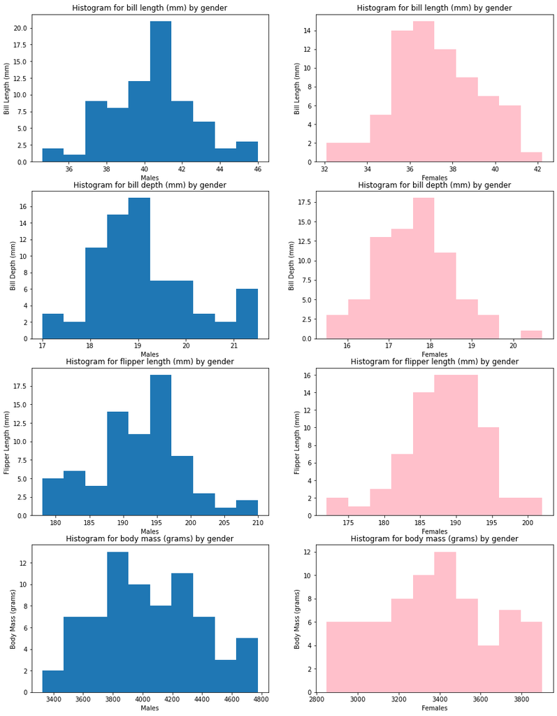

```python
# Isolating Adelie Penguin Data
adelie_data = df[df["Species"].str.contains("Adelie")]
adelie_data.reset_index(inplace = True, drop = True)

#Isolating into male versus female adelie penguins
male_data_adelie = adelie_data[adelie_data["Sex"] == 0]
female_data_adelie = adelie_data[adelie_data["Sex"] == 1]


fig, ax = plt.subplots(4,2, figsize = (15,20))
ax[0,0].hist(male_data_adelie["Bill length (mm)"])
ax[0,0].set_xlabel("Males")
ax[0,0].set_ylabel("Bill Length (mm)")
ax[0,0].set_title("Histogram for bill length (mm) by gender")

ax[0,1].hist(female_data_adelie["Bill length (mm)"], color = "pink")
ax[0,1].set_xlabel("Females")
ax[0,1].set_ylabel("Bill Length (mm)")
ax[0,1].set_title("Histogram for bill length (mm) by gender")

ax[1,0].hist(male_data_adelie["Bill depth (mm)"])
ax[1,0].set_xlabel("Males")
ax[1,0].set_ylabel("Bill Depth (mm)")
ax[1,0].set_title("Histogram for bill depth (mm) by gender")

ax[1,1].hist(female_data_adelie["Bill depth (mm)"], color = "pink")
ax[1,1].set_xlabel("Females")
ax[1,1].set_ylabel("Bill Depth (mm)")
ax[1,1].set_title("Histogram for bill depth (mm) by gender")

ax[2,0].hist(male_data_adelie["Flipper length (mm)"])
ax[2,0].set_xlabel("Males")
ax[2,0].set_ylabel("Flipper Length (mm)")
ax[2,0].set_title("Histogram for flipper length (mm) by gender")

ax[2,1].hist(female_data_adelie["Flipper length (mm)"], color = "pink")
ax[2,1].set_xlabel("Females")
ax[2,1].set_ylabel("Flipper Length (mm)")
ax[2,1].set_title("Histogram for flipper length (mm) by gender")

ax[3,0].hist(male_data_adelie["Body mass (grams)"])
ax[3,0].set_xlabel("Males")
ax[3,0].set_ylabel("Body Mass (grams)")
ax[3,0].set_title("Histogram for body mass (grams) by gender")


ax[3,1].hist(female_data_adelie["Body mass (grams)"], color = "pink")
ax[3,1].set_xlabel("Females")
ax[3,1].set_ylabel("Body Mass (grams)")
ax[3,1].set_title("Histogram for body mass (grams) by gender")

fig.savefig("adelie_gender_diff.png")
```

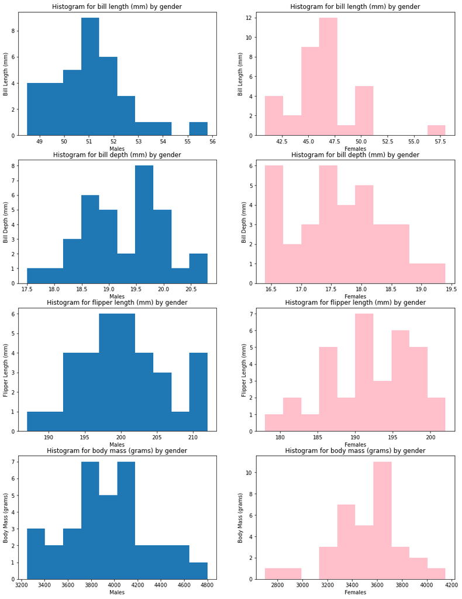

```python
# Isolating Chinstrap Penguin Data
chin_data = df[df["Species"].str.contains("Chinstrap")]
chin_data.reset_index(inplace = True, drop = True)

#Isolating into male versus female adelie penguins
male_data_chin = chin_data[chin_data["Sex"] == 0]
female_data_chin = chin_data[chin_data["Sex"] == 1]

fig, ax = plt.subplots(4,2, figsize = (15,20))
ax[0,0].hist(male_data_chin["Bill length (mm)"])
ax[0,0].set_xlabel("Males")
ax[0,0].set_ylabel("Bill Length (mm)")
ax[0,0].set_title("Histogram for bill length (mm) by gender")

ax[0,1].hist(female_data_chin["Bill length (mm)"], color = "pink")
ax[0,1].set_xlabel("Females")
ax[0,1].set_ylabel("Bill Length (mm)")
ax[0,1].set_title("Histogram for bill length (mm) by gender")

ax[1,0].hist(male_data_chin["Bill depth (mm)"])
ax[1,0].set_xlabel("Males")
ax[1,0].set_ylabel("Bill Depth (mm)")
ax[1,0].set_title("Histogram for bill depth (mm) by gender")

ax[1,1].hist(female_data_chin["Bill depth (mm)"], color = "pink")
ax[1,1].set_xlabel("Females")
ax[1,1].set_ylabel("Bill Depth (mm)")
ax[1,1].set_title("Histogram for bill depth (mm) by gender")

ax[2,0].hist(male_data_chin["Flipper length (mm)"])
ax[2,0].set_xlabel("Males")
ax[2,0].set_ylabel("Flipper Length (mm)")
ax[2,0].set_title("Histogram for flipper length (mm) by gender")

ax[2,1].hist(female_data_chin["Flipper length (mm)"], color = "pink")
ax[2,1].set_xlabel("Females")
ax[2,1].set_ylabel("Flipper Length (mm)")
ax[2,1].set_title("Histogram for flipper length (mm) by gender")

ax[3,0].hist(male_data_chin["Body mass (grams)"])
ax[3,0].set_xlabel("Males")
ax[3,0].set_ylabel("Body Mass (grams)")
ax[3,0].set_title("Histogram for body mass (grams) by gender")

ax[3,1].hist(female_data_chin["Body mass (grams)"], color = "pink")
ax[3,1].set_xlabel("Females")
ax[3,1].set_ylabel("Body Mass (grams)")
ax[3,1].set_title("Histogram for body mass (grams) by gender")

fig.savefig("chin_gender_diff.png")
```

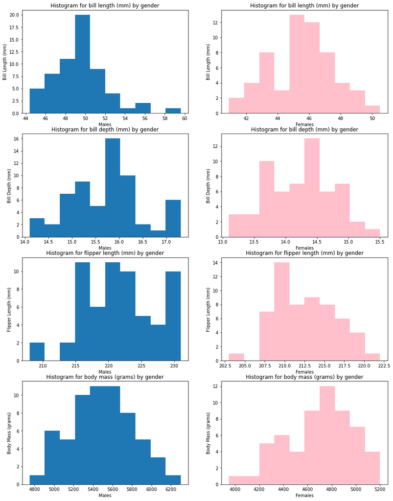

```python
# Isolating Chinstrap Penguin Data
gent_data = df[df["Species"].str.contains("Gentoo")]
gent_data.reset_index(inplace = True, drop = True)

#Isolating into male versus female adelie penguins
male_data_gent = gent_data[gent_data["Sex"] == 0]
female_data_gent = gent_data[gent_data["Sex"] == 1]

fig, ax = plt.subplots(4,2, figsize = (15,20))
ax[0,0].hist(male_data_gent["Bill length (mm)"])
ax[0,0].set_xlabel("Males")
ax[0,0].set_ylabel("Bill Length (mm)")
ax[0,0].set_title("Histogram for bill length (mm) by gender")

ax[0,1].hist(female_data_gent["Bill length (mm)"], color = "pink")
ax[0,1].set_xlabel("Females")
ax[0,1].set_ylabel("Bill Length (mm)")
ax[0,1].set_title("Histogram for bill length (mm) by gender")

ax[1,0].hist(male_data_gent["Bill depth (mm)"])
ax[1,0].set_xlabel("Males")
ax[1,0].set_ylabel("Bill Depth (mm)")
ax[1,0].set_title("Histogram for bill depth (mm) by gender")

ax[1,1].hist(female_data_gent["Bill depth (mm)"], color = "pink")
ax[1,1].set_xlabel("Females")
ax[1,1].set_ylabel("Bill Depth (mm)")
ax[1,1].set_title("Histogram for bill depth (mm) by gender")

ax[2,0].hist(male_data_gent["Flipper length (mm)"])
ax[2,0].set_xlabel("Males")
ax[2,0].set_ylabel("Flipper Length (mm)")
ax[2,0].set_title("Histogram for flipper length (mm) by gender")

ax[2,1].hist(female_data_gent["Flipper length (mm)"], color = "pink")
ax[2,1].set_xlabel("Females")
ax[2,1].set_ylabel("Flipper Length (mm)")
ax[2,1].set_title("Histogram for flipper length (mm) by gender")

ax[3,0].hist(male_data_gent["Body mass (grams)"])
ax[3,0].set_xlabel("Males")
ax[3,0].set_ylabel("Body Mass (grams)")
ax[3,0].set_title("Histogram for body mass (grams) by gender")

ax[3,1].hist(female_data_gent["Body mass (grams)"], color = "pink")
ax[3,1].set_xlabel("Females")
ax[3,1].set_ylabel("Body Mass (grams)")
ax[3,1].set_title("Histogram for body mass (grams) by gender")

fig.savefig("gent_gender_diff.png")
```

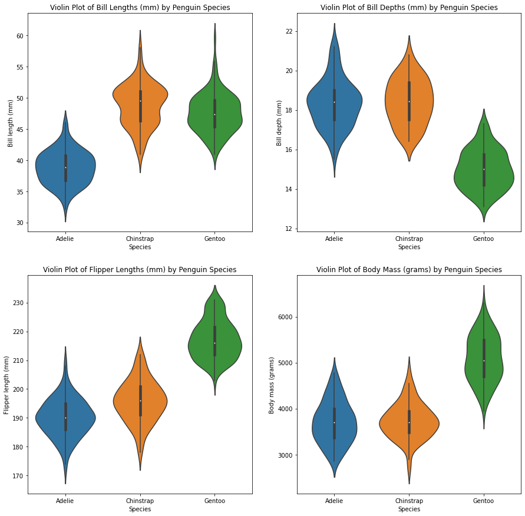

```python
# Creates violin plot using seaborn with x-axis as spec and y-axis as residuals
fig1, ax1 = plt.subplots(2,2, figsize=(15, 15))
sns.violinplot(ax = ax1[0,0],
               x=df["Species"],
               y =df["Bill length (mm)"]).set_title('Violin Plot of Bill Lengths (mm) by Penguin Species')

sns.violinplot(ax = ax1[0,1],
               x=df["Species"],
               y =df["Bill depth (mm)"]).set_title('Violin Plot of Bill Depths (mm) by Penguin Species')

sns.violinplot(ax = ax1[1,0],
               x=df["Species"],
               y =df["Flipper length (mm)"]).set_title('Violin Plot of Flipper Lengths (mm) by Penguin Species')

sns.violinplot(ax = ax1[1,1],
               x=df["Species"],
               y =df["Body mass (grams)"]).set_title('Violin Plot of Body Mass (grams) by Penguin Species')

#fig1.delaxes(ax1[1,1])

fig1.savefig("bill_lengths_violin_plot.png")
```

OLS by Species:

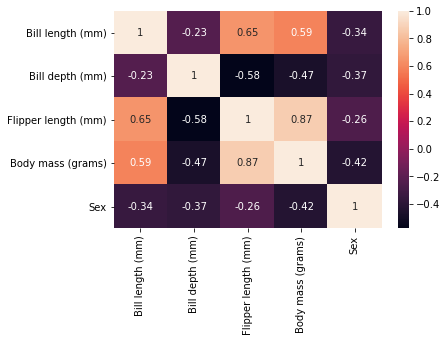

```python
# Uses statsmodel to conduct linear regression as well - uses year as the independent variable and life expectancy
# as the dependent variable
sns.heatmap(df.corr(), annot = True)
plt.show()
```

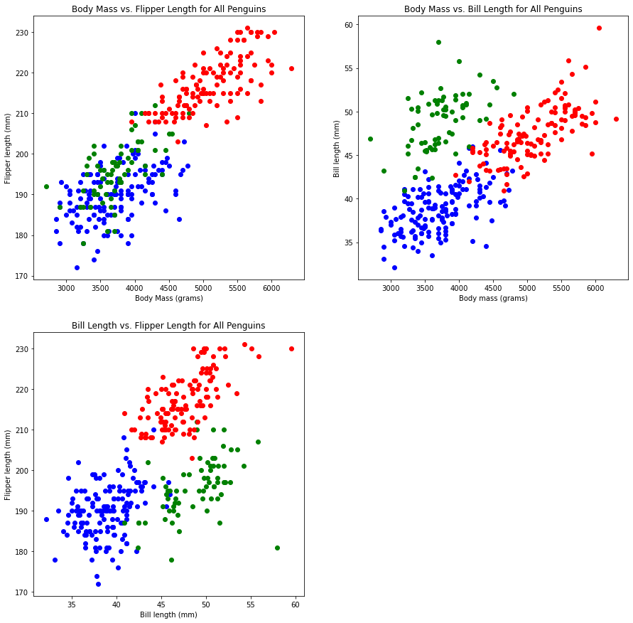

```python
fig, ax = plt.subplots(2, 2, figsize = (15,15))

ax[0, 0].scatter(adelie_data["Body mass (grams)"], adelie_data["Flipper length (mm)"], color = "blue")
ax[0, 0].scatter(chin_data["Body mass (grams)"], chin_data["Flipper length (mm)"], color = "green")
ax[0, 0].scatter(gent_data["Body mass (grams)"], gent_data["Flipper length (mm)"], color = "red")

ax[0, 0].set_xlabel("Body Mass (grams)")
ax[0, 0].set_ylabel("Flipper length (mm)")
ax[0, 0].set_title("Body Mass vs. Flipper Length for All Penguins")

# fig, ax = plt.subplots(figsize = (10,10))

ax[1, 0].scatter(adelie_data["Bill length (mm)"], adelie_data["Flipper length (mm)"], color = "blue")
ax[1, 0].scatter(chin_data["Bill length (mm)"], chin_data["Flipper length (mm)"], color = "green")
ax[1, 0].scatter(gent_data["Bill length (mm)"], gent_data["Flipper length (mm)"], color = "red")

ax[1, 0].set_xlabel("Bill length (mm)")
ax[1, 0].set_ylabel("Flipper length (mm)")
ax[1, 0].set_title("Bill Length vs. Flipper Length for All Penguins")

# fig, ax = plt.subplots(figsize = (10,10))

ax[0, 1].scatter(adelie_data["Body mass (grams)"], adelie_data["Bill length (mm)"], color = "blue")
ax[0, 1].scatter(chin_data["Body mass (grams)"], chin_data["Bill length (mm)"], color = "green")
ax[0, 1].scatter(gent_data["Body mass (grams)"], gent_data["Bill length (mm)"], color = "red")
ax[0, 1].set_xlabel("Body mass (grams)")
ax[0, 1].set_ylabel("Bill length (mm)")
ax[0, 1].set_title("Body Mass vs. Bill Length for All Penguins")

fig.delaxes(ax[1,1])
fig.savefig("bm_vs_bl.png")
```

```python
results = smf.ols("Q('Flipper length (mm)') ~ Q('Species'):Q('Body mass (grams)')",  data=df).fit()

print()
print("Statsmodel Linear Regression Results: ")
print(results.summary())
```

```
Statsmodel Linear Regression Results:
                               OLS Regression Results
====================================================================================
Dep. Variable:     Q('Flipper length (mm)')   R-squared:                       0.854
Model:                                  OLS   Adj. R-squared:                  0.853
Method:                       Least Squares   F-statistic:                     641.5
Date:                      Sun, 19 Dec 2021   Prob (F-statistic):          4.60e-137
Time:                              08:46:32   Log-Likelihood:                -1030.8
No. Observations:                       333   AIC:                             2070.
Df Residuals:                           329   BIC:                             2085.
Df Model:                                 3
Covariance Type:                  nonrobust
==================================================================================================================
                                                     coef    std err          t      P>|t|      [0.025      0.975]
------------------------------------------------------------------------------------------------------------------
Intercept                                        164.2636      2.682     61.245      0.000     158.987     169.540
Q('Species')[Adelie]:Q('Body mass (grams)')        0.0070      0.001      9.639      0.000       0.006       0.008
Q('Species')[Chinstrap]:Q('Body mass (grams)')     0.0085      0.001     11.598      0.000       0.007       0.010
Q('Species')[Gentoo]:Q('Body mass (grams)')        0.0104      0.001     19.589      0.000       0.009       0.011
==============================================================================
Omnibus:                        3.530   Durbin-Watson:                   1.769
Prob(Omnibus):                  0.171   Jarque-Bera (JB):                3.363
Skew:                          -0.173   Prob(JB):                        0.186
Kurtosis:                       3.349   Cond. No.                     2.78e+04
==============================================================================

Notes:
[1] Standard Errors assume that the covariance matrix of the errors is correctly specified.
[2] The condition number is large, 2.78e+04. This might indicate that there are
strong multicollinearity or other numerical problems.
```

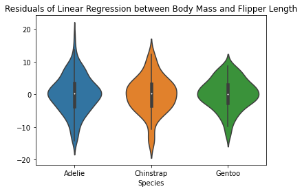

```python
# Gets the residuals from the statsmodel OLS
interaction_model_resids = results.resid

# Plots violin plot of residuals by year
fig, ax = plt.subplots()

sns.violinplot(x=df["Species"],
               y =interaction_model_resids).set_title('Residuals of Linear Regression between Body Mass and Flipper Length')
```

```python
results = smf.ols("Q('Flipper length (mm)') ~ Q('Species'):Q('Bill length (mm)')",  data=df).fit()

print()
print("Statsmodel Linear Regression Results: ")
print(results.summary())
```

```
Statsmodel Linear Regression Results:
                               OLS Regression Results
====================================================================================
Dep. Variable:     Q('Flipper length (mm)')   R-squared:                       0.831
Model:                                  OLS   Adj. R-squared:                  0.829
Method:                       Least Squares   F-statistic:                     538.6
Date:                      Sun, 19 Dec 2021   Prob (F-statistic):          1.52e-126
Time:                              08:46:32   Log-Likelihood:                -1055.3
No. Observations:                       333   AIC:                             2119.
Df Residuals:                           329   BIC:                             2134.
Df Model:                                 3
Covariance Type:                  nonrobust
=================================================================================================================
                                                    coef    std err          t      P>|t|      [0.025      0.975]
-----------------------------------------------------------------------------------------------------------------
Intercept                                       153.2507      4.741     32.321      0.000     143.923     162.578
Q('Species')[Adelie]:Q('Bill length (mm)')        0.9486      0.122      7.764      0.000       0.708       1.189
Q('Species')[Chinstrap]:Q('Bill length (mm)')     0.8724      0.098      8.929      0.000       0.680       1.065
Q('Species')[Gentoo]:Q('Bill length (mm)')        1.3454      0.100     13.470      0.000       1.149       1.542
==============================================================================
Omnibus:                        8.808   Durbin-Watson:                   1.972
Prob(Omnibus):                  0.012   Jarque-Bera (JB):               12.838
Skew:                          -0.178   Prob(JB):                      0.00163
Kurtosis:                       3.894   Cond. No.                         426.
==============================================================================

Notes:
[1] Standard Errors assume that the covariance matrix of the errors is correctly specified.
```

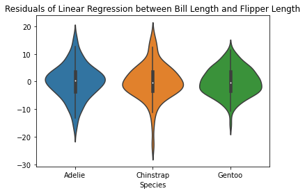

```python
# Gets the residuals from the statsmodel OLS
interaction_model_resids = results.resid

# Plots violin plot of residuals by year
fig, ax = plt.subplots()

sns.violinplot(x=df["Species"],
               y =interaction_model_resids).set_title('Residuals of Linear Regression between Bill Length and Flipper Length')
```

```python
results = smf.ols("Q('Bill length (mm)') ~ Q('Species'):Q('Body mass (grams)')",  data=df).fit()

print()
print("Statsmodel Linear Regression Results: ")
print(results.summary())
```

```
Statsmodel Linear Regression Results:
                              OLS Regression Results
=================================================================================
Dep. Variable:     Q('Bill length (mm)')   R-squared:                       0.806
Model:                               OLS   Adj. R-squared:                  0.805
Method:                    Least Squares   F-statistic:                     456.8
Date:                   Sun, 19 Dec 2021   Prob (F-statistic):          6.40e-117
Time:                           08:46:33   Log-Likelihood:                -764.39
No. Observations:                    333   AIC:                             1537.
Df Residuals:                        329   BIC:                             1552.
Df Model:                              3
Covariance Type:               nonrobust
==================================================================================================================
                                                     coef    std err          t      P>|t|      [0.025      0.975]
------------------------------------------------------------------------------------------------------------------
Intercept                                         27.8351      1.205     23.099      0.000      25.465      30.206
Q('Species')[Adelie]:Q('Body mass (grams)')        0.0030      0.000      9.140      0.000       0.002       0.004
Q('Species')[Chinstrap]:Q('Body mass (grams)')     0.0056      0.000     17.068      0.000       0.005       0.006
Q('Species')[Gentoo]:Q('Body mass (grams)')        0.0039      0.000     16.268      0.000       0.003       0.004
==============================================================================
Omnibus:                        7.403   Durbin-Watson:                   2.239
Prob(Omnibus):                  0.025   Jarque-Bera (JB):                7.881
Skew:                           0.271   Prob(JB):                       0.0194
Kurtosis:                       3.524   Cond. No.                     2.78e+04
==============================================================================

Notes:
[1] Standard Errors assume that the covariance matrix of the errors is correctly specified.
[2] The condition number is large, 2.78e+04. This might indicate that there are
strong multicollinearity or other numerical problems.
```

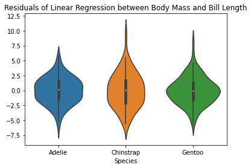

```python
# Gets the residuals from the statsmodel OLS
interaction_model_resids = results.resid

# Plots violin plot of residuals by year
fig, ax = plt.subplots()

sns.violinplot(x=df["Species"],
               y =interaction_model_resids).set_title('Residuals of Linear Regression between Body Mass and Bill Length')
```

## Machine Learning

```python
## k-NN Classification

X = df.drop(columns = "Species").values
y = df["Species"].values
#Creates dictionary of parameters

params = {"n_neighbors": [1,2,3,4,5,6,7,8,9,10], "weights" : ["uniform", "distance"]}
k_neighbors = KNeighborsClassifier()
grid_search = GridSearchCV(estimator=k_neighbors, param_grid=params, cv = 10, scoring = 'accuracy')
clf = grid_search.fit(X,y)

#Prints the best combination of parameters
print("k-NN best combination of parameters: ")
print(clf.best_params_)
print()
clf = KNeighborsClassifier(n_neighbors=1, weights="uniform")
scores = cross_val_score(clf, X, y, cv=10, scoring = 'accuracy')
print("k-NN Classification has %0.2f accuracy with a standard deviation of %0.2f" % (scores.mean(), scores.std()))
print()
print()

## Decision Tree (Classification)
# Creates dictionary of parameters
params = {"criterion": ["gini", "entropy"], "splitter" : ["best", "random"], "max_depth" : [1,2,3,4,5,6,7,8,9,10],
         "max_features" : ["auto", "sqrt", "log2"]}

decision_tree = DecisionTreeClassifier(random_state=0)

# Performs grid search
grid_search = GridSearchCV(estimator=decision_tree, param_grid=params, cv = 10, scoring = 'accuracy')
clf = grid_search.fit(X,y)

#Prints the best combination of parameters
print("Decision Tree best combination of parameters: ")
print(clf.best_params_)
print()
# Performs 10-fold cross validation with the identified best parameters
clf = DecisionTreeClassifier(criterion = "entropy", random_state=0, splitter='best', max_features = 'auto', max_depth = 4)

# Using accuracy as the scoring metric
scores = cross_val_score(clf, X, y, cv=10, scoring = 'accuracy')

# Prints the mean and standard deviation accurary of decision tree classification
print("Decision Tree has %0.2f accuracy with a standard deviation of %0.2f" % (scores.mean(), scores.std()))

## Random Forest  (Classification)

# Creates dictionary of parameters
params = {"n_estimators": [1, 10, 100], "criterion": ["gini", "entropy"], "max_depth" : [1,2,3,4,5,6,7,8],
          "max_features" : ["auto", "sqrt", "log2"]}

random_forest = RandomForestClassifier(random_state=0)

# Performs grid search
grid_search = GridSearchCV(estimator=random_forest, param_grid=params, cv = 10, scoring = 'accuracy')
clf = grid_search.fit(X,y)

#Prints the best combination of parameters
print("Random Forest best combination of parameters: ")
print(clf.best_params_)
print()
# Performs 10-fold cross validation with the identified best parameters
clf = RandomForestClassifier(criterion = "entropy", n_estimators = 100, random_state=0, max_features = 'auto', max_depth = 7)

# Using accuracy as the scoring metric
scores = cross_val_score(clf, X, y, cv=10, scoring = 'accuracy')

# Prints the mean and standard deviation accurary of decision tree classification

print("Random Forest has %0.2f accuracy with a standard deviation of %0.2f" % (scores.mean(), scores.std()))
```

```
k-NN best combination of parameters:
{'n_neighbors': 1, 'weights': 'uniform'}

k-NN Classification has 0.86 accuracy with a standard deviation of 0.05


Decision Tree best combination of parameters:
{'criterion': 'entropy', 'max_depth': 4, 'max_features': 'auto', 'splitter': 'best'}

Decision Tree has 0.95 accuracy with a standard deviation of 0.02
Random Forest best combination of parameters:
{'criterion': 'entropy', 'max_depth': 7, 'max_features': 'auto', 'n_estimators': 100}

Random Forest has 0.98 accuracy with a standard deviation of 0.02
```